# Metabarcoding Assignment

mstewart2000

15/03/2022

GitHub Link: https://github.com/mstewart2000/Metabarcoding-Assignment.git

##Initial Setup

#Setting up packages

These are the packages I will need for this assignment

[output not shown]

Loading in Data

```r
Samples = read.csv("./Data/FloristicSurvey.csv")
```

# Cleaning up data

I will remove much of the data to get what matters, the number of each species per quadrate, along with making each sample have the name of the quadrate it was taken in

```r
Samples = Samples %>%
  rename(Quadrate = ï..Quadrate)
Samples_Sub = Samples %>%
  select(11:44)
row.names(Samples_Sub) = Samples$Quadrate
head(Samples_Sub)
```

```
##     Claytonia_virginiana Anemone_hepatica Grass_tuft Trillium_grandifolium
## 7o3                   38                8         14                     9
## 7o1                   29                7         22                    30
## 7o2                   57                3          6                     8
## 7i3                   22                0         10                     0
## 7i2                   54                0          3                     0
## 7i1                   44                0          0                     0
##     Erythronium.trout.lily. Acer_saccharum Dicentra_cucularia Bloodroot
## 7o3                      25              5                  0         0
## 7o1                      10             10                 22         4
## 7o2                       5             74                 23         0
## 7i3                      16              0                  0         0
## 7i2                      18              2                  0         1
## 7i1                       7              0                  0         0
##     Gallium_aparine Ulmus_americana Unknown_1 Unknown_2
## 7o3               0               0         0         0
## 7o1              27               3         1         0
## 7o2               8               0         0         0
## 7i3              17              88         0         5
## 7i2              22             150         0         4
## 7i1              21             133         0         4
##     Unknown_3.rannunculaceae. Unknown_4 Dryopteris_marginalis Ostrich_fern
## 7o3                         0         0                     0            0
## 7o1                         0         0                     0            0
## 7o2                         0         0                     0            0
## 7i3                         0         0                     0            0
## 7i2                         0         0                     0            0
## 7i1                         0         0                     0            0
##     Plantago_lanceolata Violet Rhamnus_frangula Raspberry Unknown_5 Unknown_6
## 7o3                   0      0                0         0         0         0
## 7o1                   0      0                0         0         0         0
## 7o2                   0      0                0         0         0         0
## 7i3                   0      0                0         0         0         0
## 7i2                   0      0                0         0         0         0
## 7i1                   0      0                0         0         0         0
##     Solidago_canadensis Unknown_7 Dandelion grass viccia_cracca herb_robert
## 7o3                   0         0         0     0             0           0
## 7o1                   0         0         0     0             0           0
## 7o2                   0         0         0     0             0           0
## 7i3                   0         0         0     0             0           0
## 7i2                   0         0         0     0             0           0
## 7i1                   0         0         0     0             0           0
##     thorny_ash rhamnus_cathartica rhubarb Unknown_8 Unknown_9
## 7o3          0                  0       0         0         0
## 7o1          0                  0       0         0         0
## 7o2          0                  0       0         0         0
## 7i3          0                  0       0         0         0
## 7i2          0                  0       0         0         0
## 7i1          0                  0       0         0         0
##     maianthenum_racemosum
## 7o3                     0
## 7o1                     0
## 7o2                     0
## 7i3                     0
## 7i2                     0
## 7i1                     0
```

I will save this new data frame to upload to my assignment later

```r
write.csv(Samples_Sub, file = "SampleSubset.csv")
```

# Bray-Curtis

I will now make a bray-curtis distance matrix to see what effect garlic mustard has on the plant community

```r
Sample_dist = vegdist(Samples_Sub, method = "bray", binary = F)
Samples_tree = nj(Sample_dist)
```

Now I will make the tree

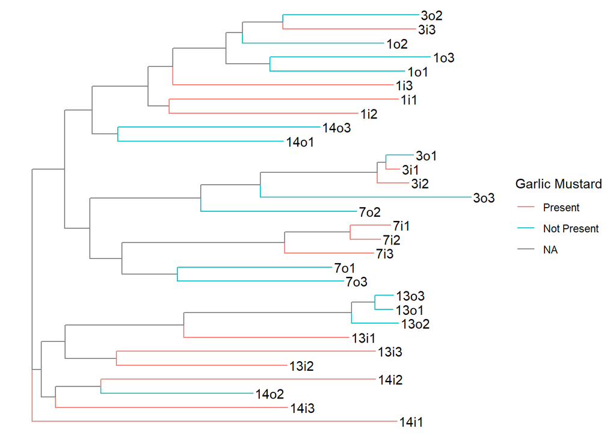

```r
ggtree(Samples_tree, layout = "rectangular") %<+% Samples +
 geom_tree(aes(colour = Location)) +
  geom_tiplab() +
  scale_colour_discrete(name = "Garlic Mustard", labels = c("Present", "Not Present"))
```

Just based on this graph, it is not let possible to tell if there is a difference yet, so I will use NMDS to make a better determination

# NMDS

This will allow me to more accurately compare the effects of the presence of Garlic Mustard vs the Location of the sample

To start I will generate it

```r
set.seed(13)
NMDSdat = metaMDS(Sample_dist, k = 2, trymax = 100)
```

```
## *** Solution reached
```

Now I will create data for plotting

```r
PDat = data.frame(NMDS1 = NMDSdat$points[,1],
                  NMDS2 = NMDSdat$points[,2],
                  Quadrate = row.names(Samples_Sub))
```

Now I will add labels

```r
PDat = merge(PDat, Samples, by = "Quadrate", all.x = T, all.y = T)
```

Now I will plot the populations as well as including the locations

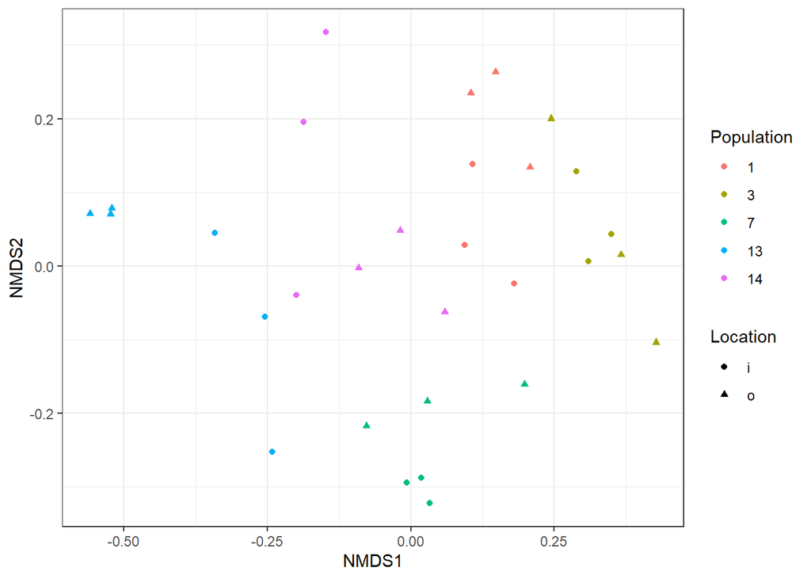

```r
ggplot(PDat) +
  geom_point(aes(x = NMDS1, y = NMDS2, colour = factor(Population), shape = Location)) +
  scale_colour_discrete(name = "Population") +
  theme_bw()
```

As this plot shows, there is little correlation between the location of the samples and a much greater correlation between the population and the sample.